# Hotel Review Analysis

Vidya

24 October 2018

## Sentiment Analysis of Hotel Reviews.

### Data Analysis Domain: Text Analytics

### Business Domain: Hospitality Industry.

### Data Source : https://archive.ics.uci.edu/ml/datasets/Eco-hotel

### The data consists of online reviews , both online (TripAdvisor) and offline (e.g.,

### Guests’ book) sources from the Areias do Seixo Eco-Resort.

### All the 401 reviews were collected between January and August of 2015.

### **Data Analysis Objective:**

- to be able to segregate the positive and negative words in the reviews
- to know what are the most good and bad factors experienced by the guests
- to be able to flag the review as a positive feedback or a negative one.(This analysis restricts the scope to either ‘positive’ or ‘negative’. Future work will involve further classification to other sentiments.)

### Glimpse of some reviews.

```
## [1] " Everything from the weather, staff, food, property, fire pits, décor, spa, rooms and beach were top notch"
## [2] "The hotel it is fantastic built by the sea, living together with nature. Environment it is great as well as people and service.\nWe full enjoyed the place, and facilities.\nThanks for the \"cidreira\" and \"madalenas\" tea at reception"
## [3] "One dream! Cozy  and comfortable Hotel!  The best personalized one! All the employees are congratulated! Very nice taste, since reception to the end of the stay! We were welcome with tea and cake, as I have gluten aversion,, all the employees already knew and were waiting carefully. At night…
## [4] "Hotel concept is hard to grasp. They communicate environmental sustainability, through fashionable buzzwords like upcycling but they use pillows made out of duck feathers!?!\nPricing is utterly ridiculous, for what you get.\nBreakfast has high-quality products, but it lacks in choice.\nServi…
```

### These reviews are split into single words and common words such as pronouns , conjunctions , preposition are filtered out. The remaining words are counted to know the maximum usage in the review.

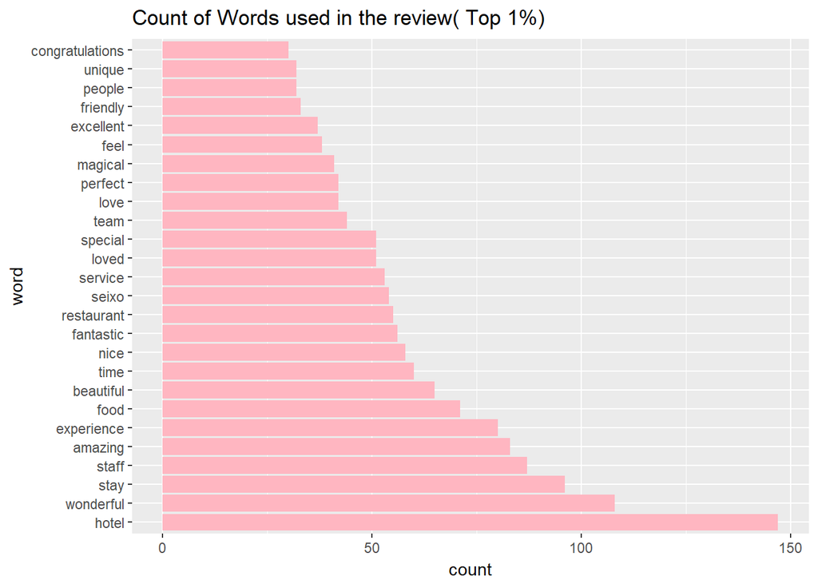

### A look into the most common words by their frequencies in the review.

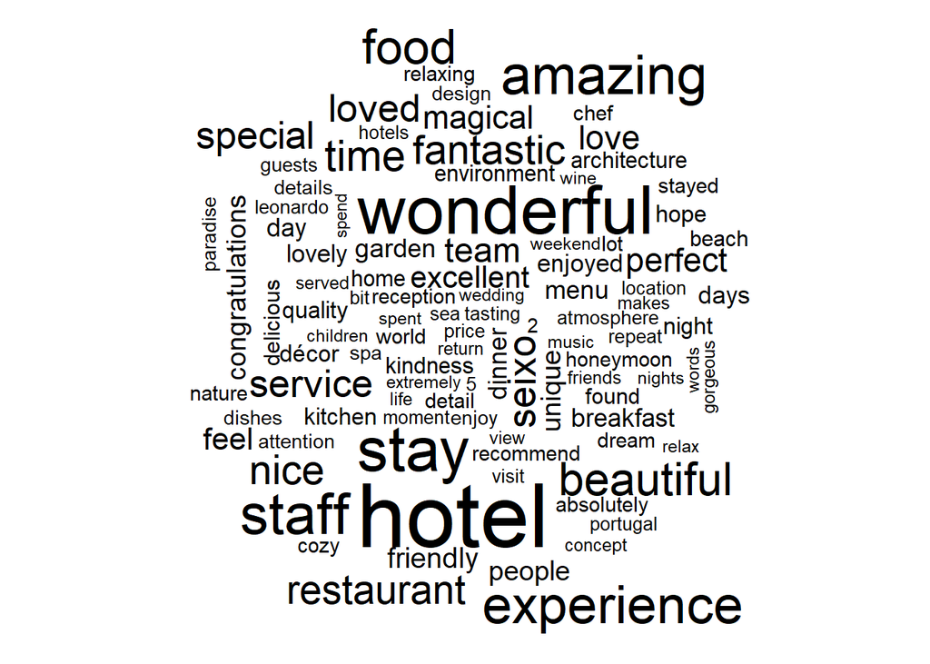

### Among the words used in the review , how many are positive meaning and their count ?

### For this purpose , ‘nrc’ lexicon is used to reference the positive and negative meaning words.This analysis restricts the scope of identification to ‘positive’ /‘negative’ .

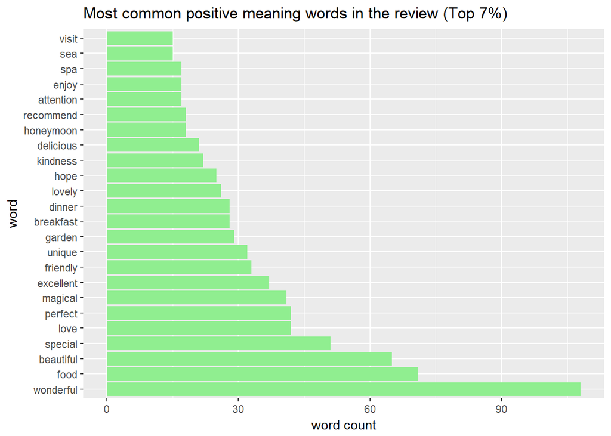

### Word cloud of positive words by their frequency in the reviews

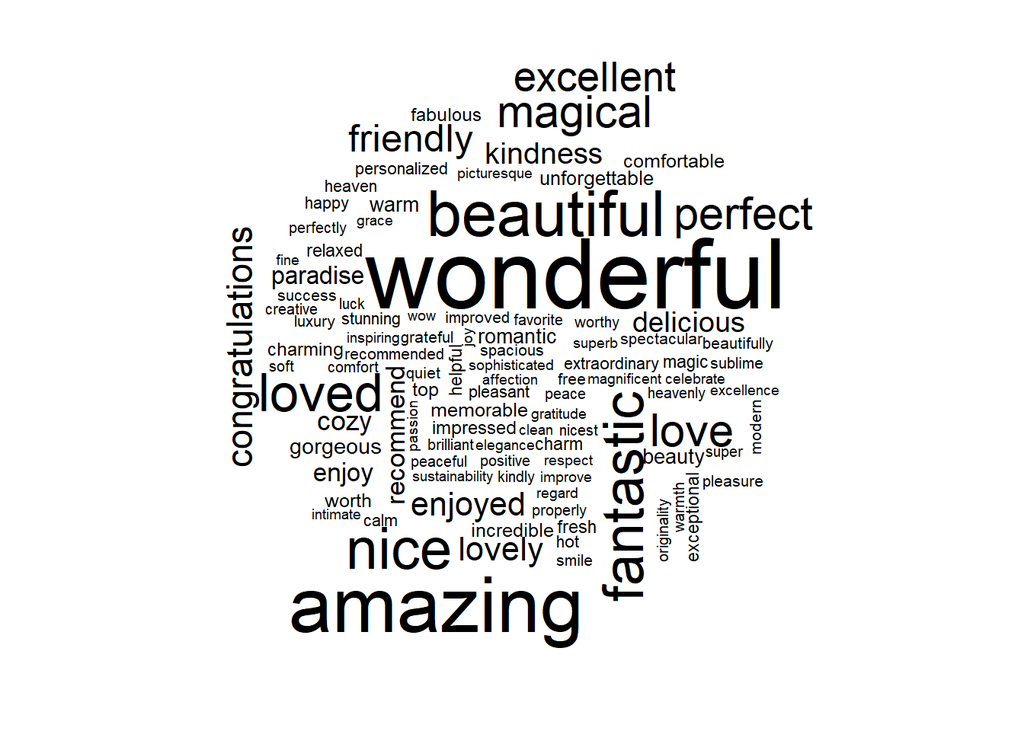

### Among the words used in the review , how many are negative meaning and their count ?

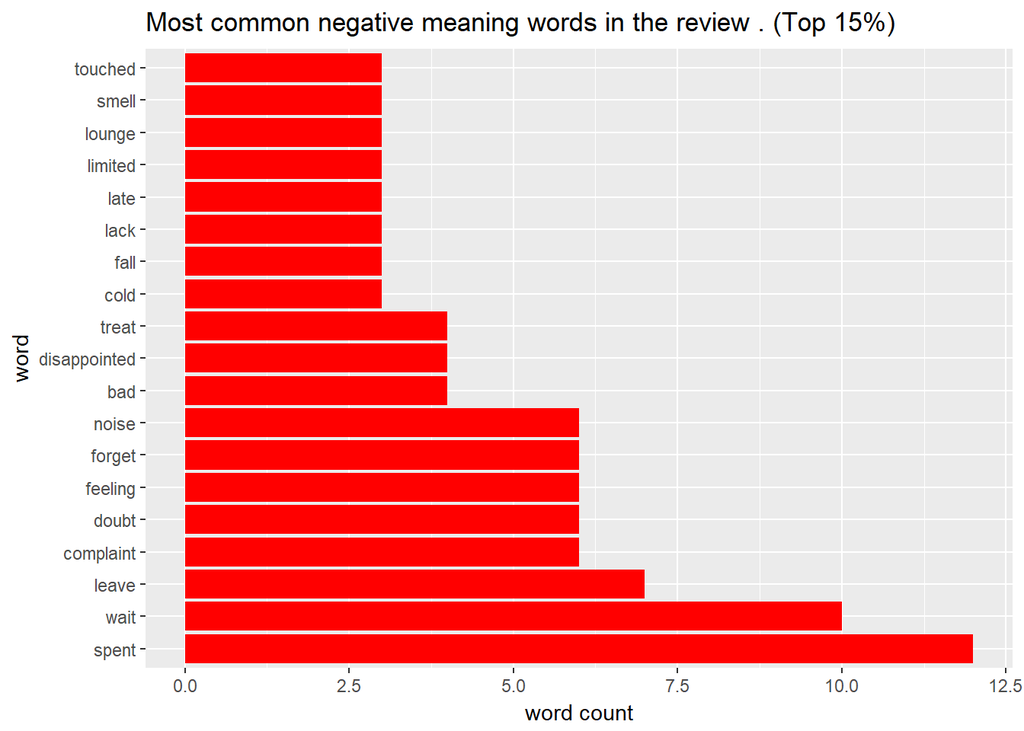

### Word cloud of negative words by their frequency in the reviews

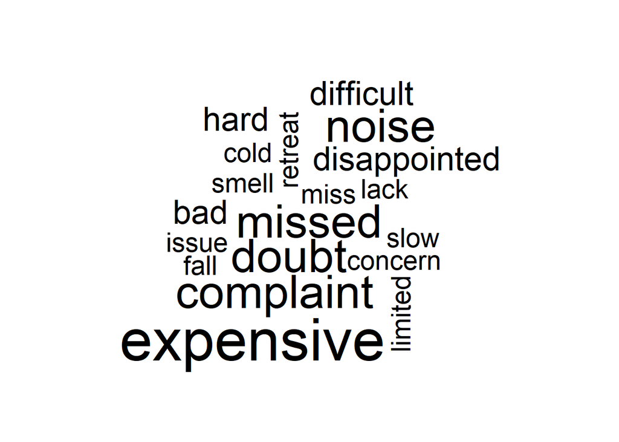

### To undestand the context , review is broken by dual words . This is done so that we can look out for negators or enhancers in front of a positive meaning or negative meaning word. First , lets look at the most commonly used dual words.

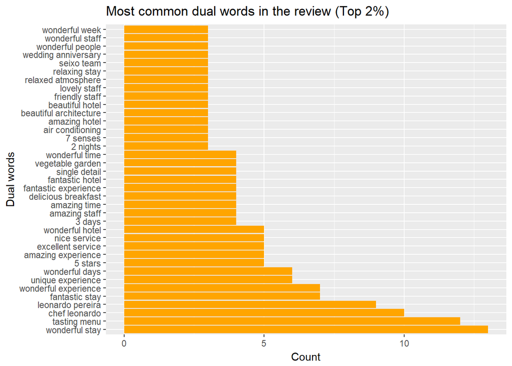

### Dual words and their frequency as word cloud .

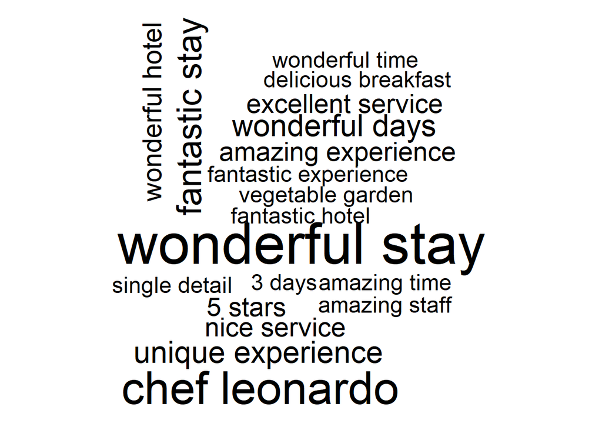

### It looks like the most of the reviews may be positive as the most of the common dual words used in the review appear to be positive meaning.

### Most commonly used dual words are further seperated into positive /negative meaning and as follows-

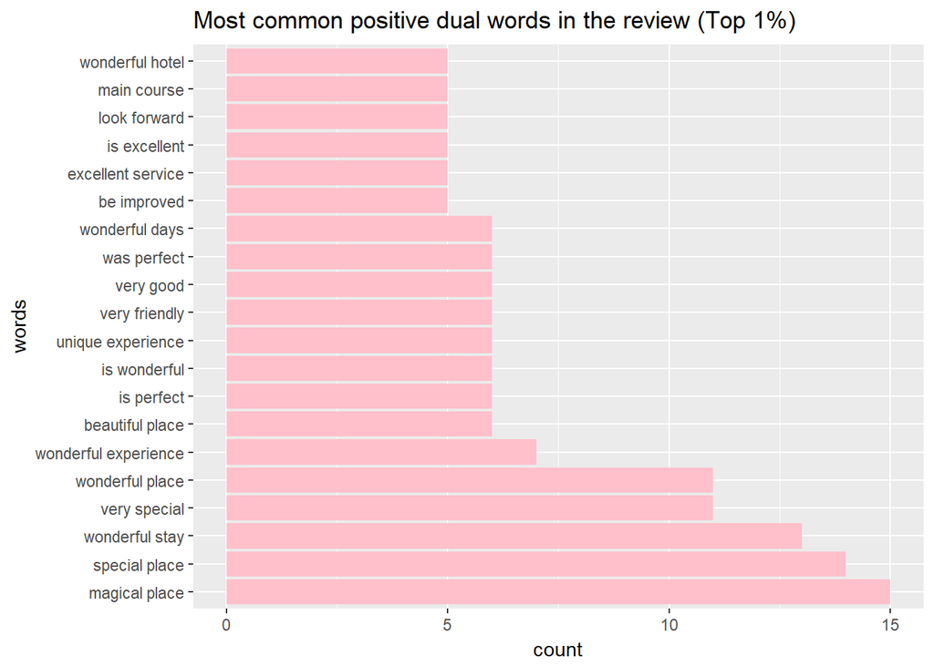

### Frequency of positive dual words in the review as word cloud

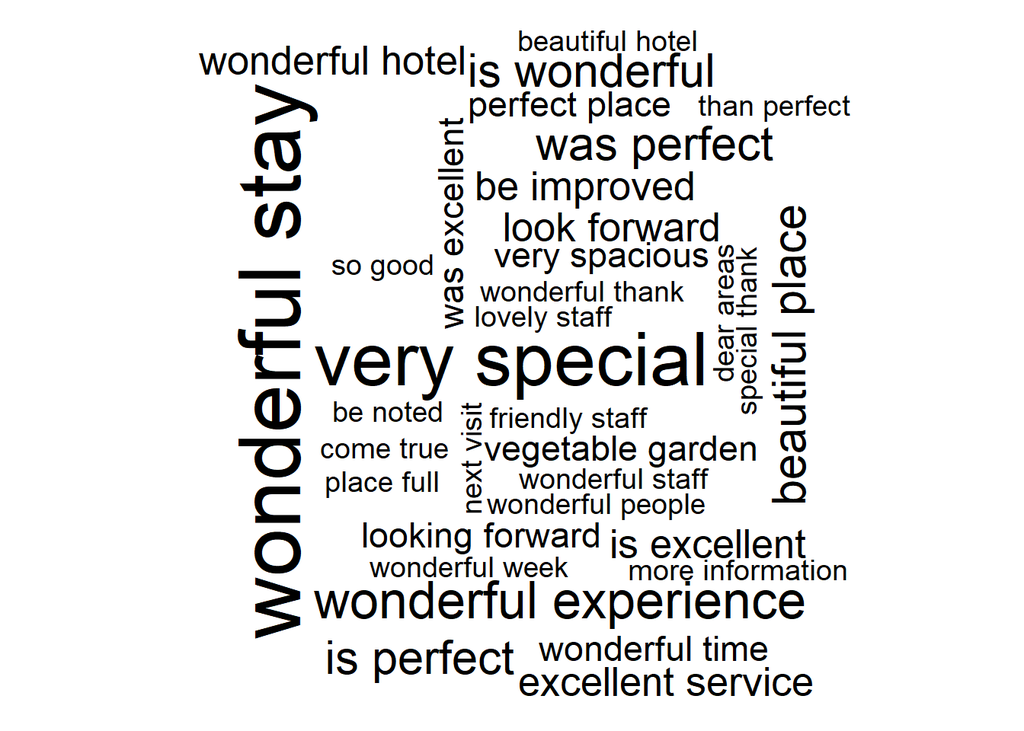

### Reviews are further analyzed for finding out the positive and negative meaning adjectives/nouns/adverbs.

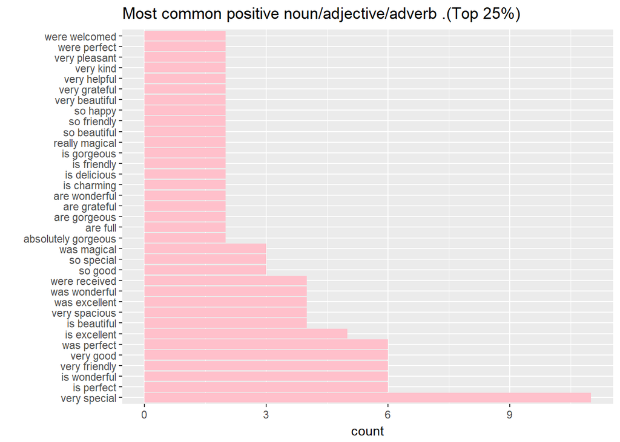

### Word Cloud of positive meaning adjective/adverb/pronoun

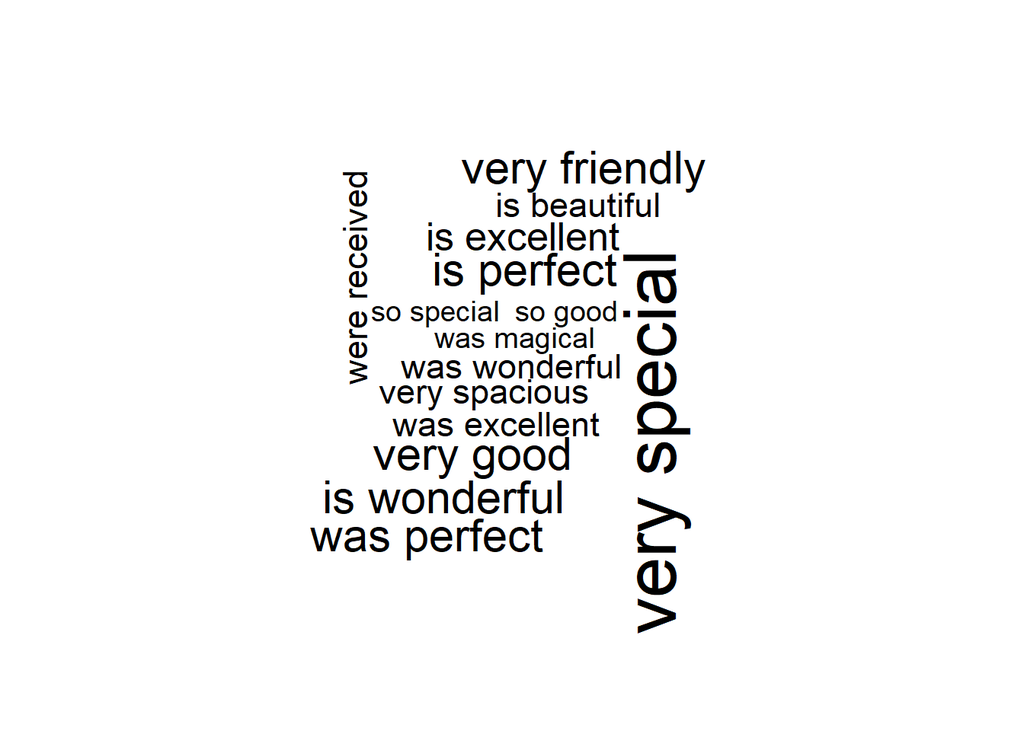

### When positive meaning words are negated with a ‘not’ or ‘isn’t’ in front of it , it means a negative sentiment.Filter out such dual words as shown below.

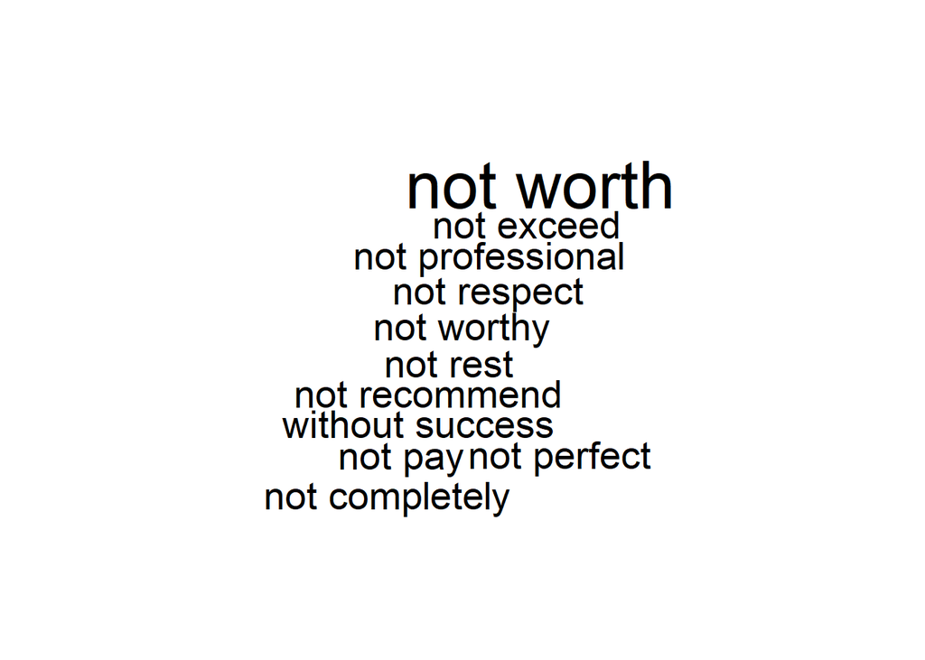

### Looking at negative sentiment in the review . These are part of reviews which express something negative.

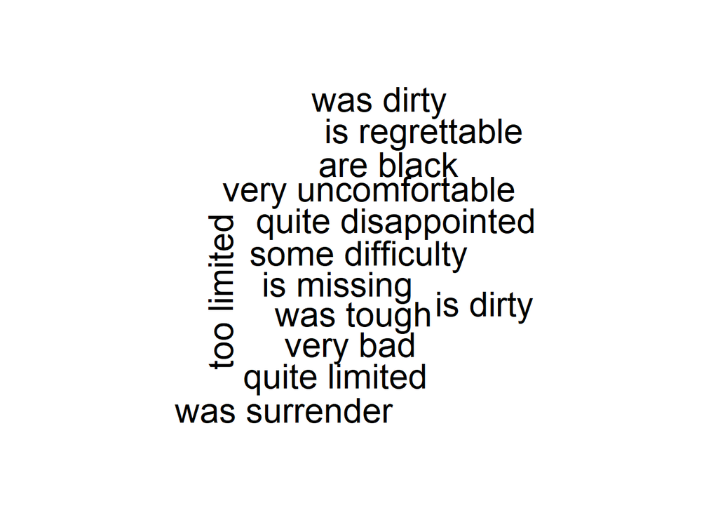

### Negation of negative meaning words , which means a positive sentiment.

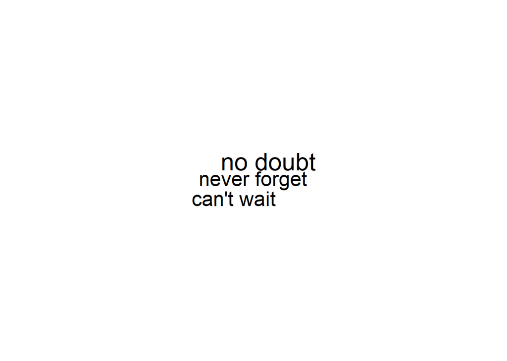

### As shown above , each review is marked for its positive and negative sentiments.

### By counting each of them , we get it an overall sentiment feel of the review.

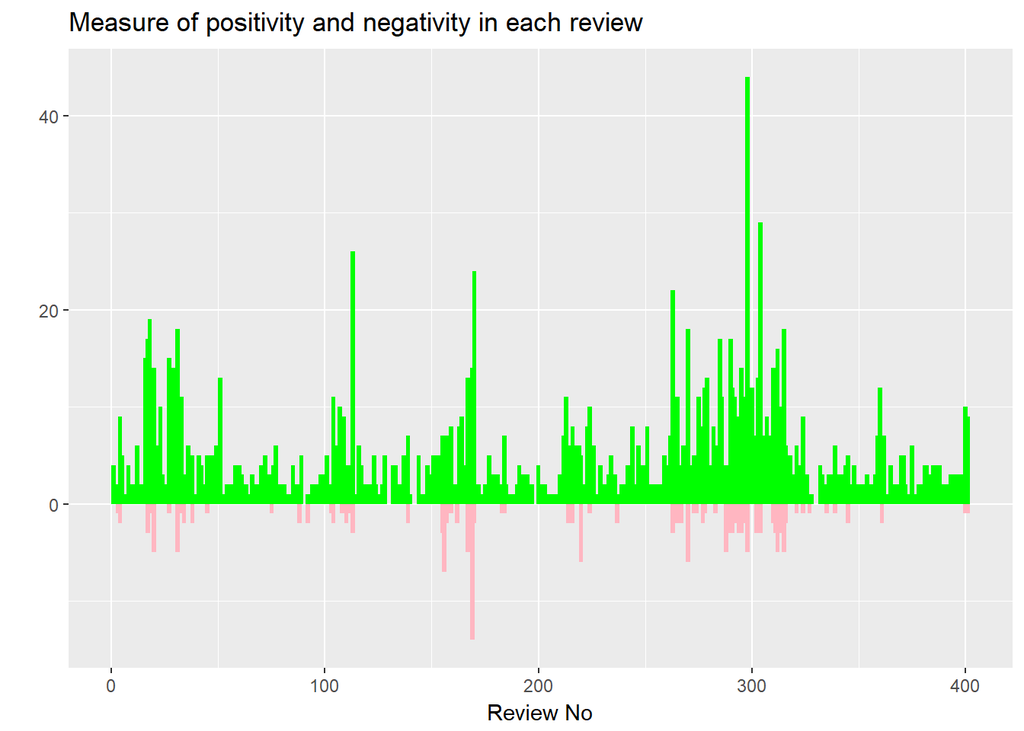

### Which are the reviews that need scrutiny ? i.e have all/more negative sentiments than positive ?

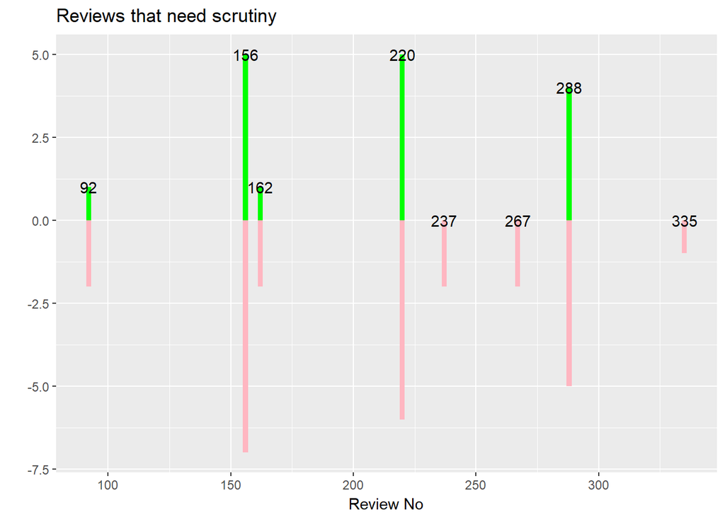